# Report

# General characterization

## Additive model

We have characterized the ecological conditions that promote divergence for our chemostat-dynamics model. They are similar to the results of Ripa et al. and Rettelbach et al. in that ecological divergence occurs for a narrow range of divergent selction intensity in more homogeneous landscapes (this corresponds to migration-independent competitive speciation), but under a wide range of (low) divergent selection intensities in very heterogeneous landscapes (migration-driven ecological speciation).

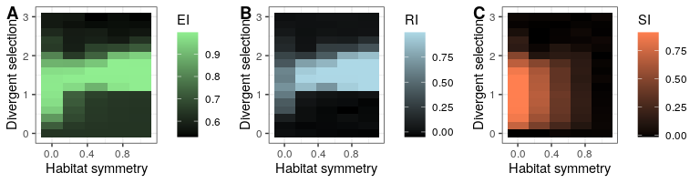

Reproductive isolation does not evolve as often in the migration-driven scenario. It actually arises very slowly.

On the contrary, in this scenario ecotype differentiation happens very fast compared to non-fully-heterogeneous landscapes, even in the absence of a strong trade-off:

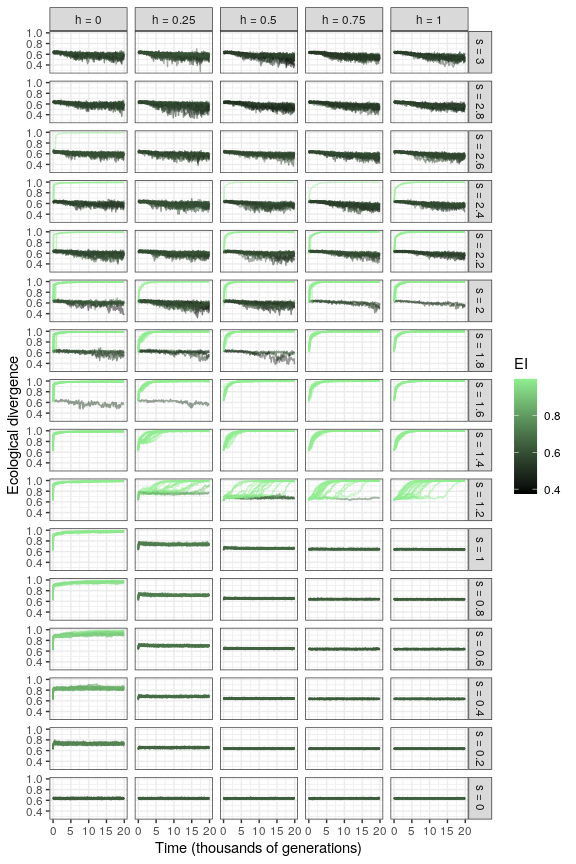

The final spatial distribution is often achieved early during the simulations, and it very well determined by the degree of habitat symmetry:

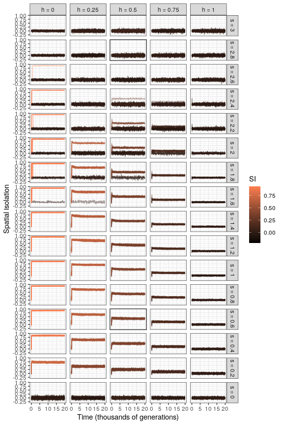

We see in these figures that the simulations usually fisrt converge to a transition phase of incomplete ecological differentiation with a higher spatial differentiation than their final value. In a second phase coinciding with the rise of reproductive isolation, ecological differentiation completes and spatial isolation decreases to its equilibrium value. It is best seen when plotting the variables against each other:

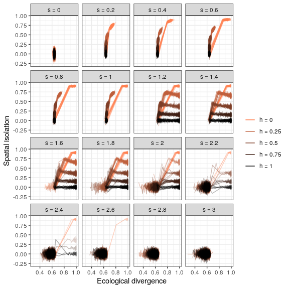

## Epistatic genotype-phenotype map

We characterized the behavior of the model, this time with the ecological trait underlain by a gene regulatory network. The network of epistatic interactions either entirely determined the phenotype ($\sigma_I = 1$) or partially, with equal contribution from the additive component of the genotype-phenotype map ($\sigma_I = 0.5$). We compared the results with the additive model presented in the previous section ($\sigma_I = 0$).

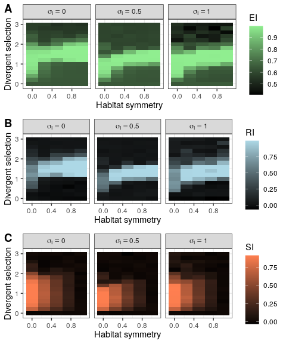